# W3cubDocs

/D3.js 5

# d3-voronoi

**Deprecation notice**: Consider using the newer d3-delaunay instead of d3-voronoi. Based on [Delaunator](https://github.com/mapbox/delaunator), d3-delaunay is 5-10× faster than d3-voronoi to construct the Delaunay triangulation or the Voronoi diagram, is more robust numerically, has Canvas rendering built-in, allows traversal of the Delaunay graph, and a variety of other improvements.

This module implements [Steven J. Fortune’s algorithm](https://en.wikipedia.org/wiki/Fortune's_algorithm) for computing the [Voronoi diagram](https://en.wikipedia.org/wiki/Voronoi_diagram) or [Delaunay triangulation](https://en.wikipedia.org/wiki/Delaunay_triangulation) of a set of two-dimensional points. This implementation is largely based on [work by Raymond Hill](http://www.raymondhill.net/voronoi/rhill-voronoi.html).

Voronoi diagrams are not only [visually](http://bl.ocks.org/mbostock/4360892) [attractive](http://bl.ocks.org/mbostock/4636377) but practical tools for interaction, such as to increase the target area of points in a scatterplot. See [“Strikeouts on the Rise”](http://www.nytimes.com/interactive/2013/03/29/sports/baseball/Strikeouts-Are-Still-Soaring.html) in *The New York Times* and this [multi-line chart](http://bl.ocks.org/mbostock/8033015) for examples; also see Tovi Grossman’s paper on [bubble cursors](http://www.tovigrossman.com/BubbleCursor) for a related technique. Voronoi diagrams can also be used to [automate label positioning](http://bl.ocks.org/mbostock/6909318), and Delaunay meshes are useful in computing adjacency or grouping of visual elements.

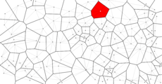

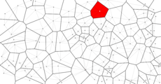

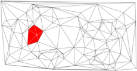

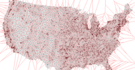

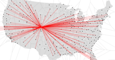

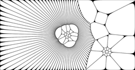

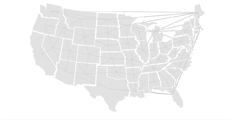

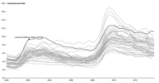

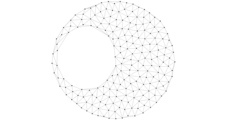

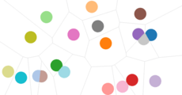

## Installing

If you use NPM, `npm install d3-voronoi`. Otherwise, download the [latest release](https://github.com/d3/d3-voronoi/releases/latest). You can also load directly from d3js.org, either as a [standalone library](https://d3js.org/d3-voronoi.v1.min.js) or as part of [D3 4.0](https://github.com/d3/d3). AMD, CommonJS, and vanilla environments are supported. In vanilla, a `d3` global is exported:

```
<script src="https://d3js.org/d3-voronoi.v1.min.js"></script>
<script>

var voronoi = d3.voronoi();

</script>
```

[Try d3-voronoi in your browser.](https://tonicdev.com/npm/d3-voronoi)

## API Reference

###### d3.**voronoi**() [Source](https://github.com/d3/d3-voronoi/blob/master/src/voronoi.js)

Creates a new Voronoi layout with default *x*- and *y*- accessors and a null extent.

###### *voronoi*(*data*) [Source](https://github.com/d3/d3-voronoi/blob/master/src/voronoi.js#L10)

Computes the Voronoi diagram for the specified *data* points.

###### *voronoi*.**x**([*x*]) [Source](https://github.com/d3/d3-voronoi/blob/master/src/voronoi.js#L31)

If *x* is specified, sets the *x*-coordinate accessor. If *x* is not specified, returns the current *x*-coordinate accessor, which defaults to:

```
function x(d) {
  return d[0];
}
```

###### *voronoi*.**y**([*y*]) [Source](https://github.com/d3/d3-voronoi/blob/master/src/voronoi.js#L35)

If *y* is specified, sets the *y*-coordinate accessor. If *y* is not specified, returns the current *y*-coordinate accessor, which defaults to:

```
function y(d) {
  return d[1];
}
```

###### *voronoi*.**extent**([*extent*]) [Source](https://github.com/d3/d3-voronoi/blob/master/src/voronoi.js#L39)

If *extent* is specified, sets the clip extent of the Voronoi layout to the specified bounds and returns the layout. The *extent* bounds are specified as an array [[*x0*, *y0*], [*x1*, *y1*]], where *x0* is the left side of the extent, *y0* is the top, *x1* is the right and *y1* is the bottom. If *extent* is not specified, returns the current clip extent which defaults to null. A clip extent is required when using *voronoi*.polygons.

###### *voronoi*.**size**([*size*]) [Source](https://github.com/d3/d3-voronoi/blob/master/src/voronoi.js#L43)

An alias for *voronoi*.extent where the minimum *x* and *y* of the extent are ⟨0,0⟩. Equivalent to:

```
voronoi.extent([[0, 0], size]);
```

###### *voronoi*.**polygons**(*data*) [Source](https://github.com/d3/d3-voronoi/blob/master/src/voronoi.js#L19)

Returns a sparse array of polygons, one for each unique input point in the specified *data* points, corresponding to the cells in the computed Voronoi diagram. Equivalent to:

```
voronoi(data).polygons();
```

See *diagram*.polygons for more detail. Note: an extent is required.

###### *voronoi*.**triangles**(*data*) [Source](https://github.com/d3/d3-voronoi/blob/master/src/voronoi.js#L27)

Returns the Delaunay triangulation of the specified *data* array as an array of triangles. Each triangle is a three-element array of elements from *data*. Equivalent to:

```
voronoi(data).triangles();
```

See *diagram*.triangles for more detail.

###### *voronoi*.**links**(*data*) [Source](https://github.com/d3/d3-voronoi/blob/master/src/voronoi.js#L23)

Returns the Delaunay triangulation of the specified *data* array as an array of links. Each link has `source` and `target` attributes referring to elements in *data*. Equivalent to:

```
voronoi(data).links();
```

See *diagram*.links for more detail.

### Voronoi Diagrams

###### *diagram* [Source](https://github.com/d3/d3-voronoi/blob/master/src/Diagram.js)

The computed Voronoi diagram returned by *voronoi* has the following properties:

- `edges` - an array of edges.
- `cells` - a sparse array of cells, one for each unique input point.

For each set of coincident input points, one of the points is chosen arbitrarily and assigned the associated cell; the other coincident input points’ entries are missing from the returned sparse array.

###### *diagram*.**polygons**() [Source](https://github.com/d3/d3-voronoi/blob/master/src/Diagram.js#L72)

Returns a sparse array of polygons clipped to the *extent*, one for each cell (each unique input point) in the diagram. Each polygon is represented as an array of points [*x*, *y*] where *x* and *y* are the point coordinates, and a `data` field that refers to the corresponding element in *data*. Polygons are open: they do not contain a closing point that duplicates the first point; a triangle, for example, is an array of three points. Polygons are also counterclockwise, assuming the origin ⟨0,0⟩ is in the top-left corner.

For each set of coincident input points, one of the points is chosen arbitrarily and assigned the associated polygon; the other coincident input points’ entries are missing from the returned sparse array.

###### *diagram*.**triangles**() [Source](https://github.com/d3/d3-voronoi/blob/master/src/Diagram.js#L82)

Returns the Delaunay triangulation of the specified *data* array as an array of triangles. Each triangle is a three-element array of elements from *data*. Since the triangulation is computed as the dual of the Voronoi diagram, and the Voronoi diagram is clipped by the extent, a subset of the Delaunay triangulation is returned.

###### *diagram*.**links**() [Source](https://github.com/d3/d3-voronoi/blob/master/src/Diagram.js#L108)

Returns the Delaunay triangulation of the specified *data* array as an array of links, one for each edge in the mesh. Each link has the following attributes:

- `source` - the source node, an element in *data*.
- `target` - the target node, an element in *data*.

Since the triangulation is computed as the dual of the Voronoi diagram, and the Voronoi diagram is clipped by the extent, a subset of the Delaunay links is returned.

###### *diagram*.**find**(*x*, *y*[, *radius*]) [Source](https://github.com/d3/d3-voronoi/blob/master/src/Diagram.js#L119)

Returns the nearest site to point [*x*, *y*]. If *radius* is specified, only sites within *radius* distance are considered.

See Philippe Rivière’s [bl.ocks.org/1b7ddbcd71454d685d1259781968aefc](http://bl.ocks.org/Fil/1b7ddbcd71454d685d1259781968aefc) for an example.

###### *cell*

Each cell in the diagram is an object with the following properties:

- `site` - the site of the cell’s associated input point.
- `halfedges` - an array of indexes into *diagram*.edges representing the cell’s polygon.

###### *site*

Each site in the diagram is an array [*x*, *y*] with two additional properties:

- `index` - the site’s index, corresponding to the associated input point.
- `data` - the input data corresponding to this site.

###### *edge*

Each edge in the diagram is an array [[*x0*, *y0*], [*x1*, *y1*]] with two additional properties:

- `left` - the site on the left side of the edge.
- `right` - the site on the right side of the edge; null for a clipped border edge.

© 2010–2018 Michael Bostock  
Licensed under the BSD License.  
https://github.com/d3/d3-voronoi